# Creating visual predictive checks in R

Ron Keizer

2014-10-20

The VPC is the most widely used diagnostic tool in pharmacometrics (see e.g. [here](http://page-meeting.org/default.asp?abstract=1434)), and is commonly created using [PsN](http://psn.sourceforge.net/) and [Xpose](http://xpose.sourceforge.net/), using NONMEM as the simulation engine. The aim of the current R library is to provide an improved tool that is:

- a single-step process for creating a VPC in R, without the need for PsN or Xpose.
- allows changing of vpc parameters such as binning / stratification upon creation of the plot, not in a separate pre-processing step.
- easier debugging than PsN+Xpose, all data parsing and plotting in one R function
- more flexible regarding input (use simulated data from R, NONMEM, Monolix, Stan, or any other simulation tool)
- easier to customize, e.g. request any prediction / confidence interval or binning strategy upon plotting.
- easier to extend: the output is a ggplot object which can be themed and extended
- faster

## Installation

```r
    # library("devtools")
    # install_github("ronkeizer/vpc")
    library(vpc)
```

## How to use

Functions:

- `vpc`: VPC for continuous data
- `vpc_cat`: VPC for categorical data
- `vpc_cens`: VPC for censored continuous data (e.g. data < LOQ)
- `vpc_tte`: VPC for (repeated) time-to-event data

The main arguments to these function are the `sim` and `obs` arguments, which specify a simulation dataset and an observation dataset. All other arguments can be used to customize data parsing and visual appearance of the VPC such as stratification and binning. All four functions will return a ggplot2 object.

## Examples

Load the library and get the observation data and simulation data. In the first example, we’ll use a dataset that’s available in R by default (Theophylline) and generate the simulation dataset in R.

```r
    library(dplyr)
    library(vpc)

    ## Load the theophylline PK dataset
    obs <- Theoph
    colnames(obs) <- c("id", "wt", "dose", "time", "dv")
    obs <- obs %>%
            group_by(id) %>%
            mutate(sex = round(runif(1))) # randomly assign a "sex" covariate
    sim <- sim_data(obs, # the design of the dataset
                    model = function(x) { # the model
                      pk_oral_1cmt (t = x$time, dose=x$dose * x$wt, ka = x$ka, ke = x$ke, cl = x$cl * x$wt)
                    },
                    error = list(additive = 0.1),
                    theta = c(2.774, 0.0718, .0361),                 # parameter values
                    omega_mat = c(0.08854,                           # specified as lower triangle by default;
                                  0.02421, 0.02241,                  # note: assumed that every theta has iiv, set to 0 if no iiv.
                                  0.008069, 0.008639, 0.02862),
                    par_names = c("ka", "ke", "cl"),                 # link the parameters in the model to the thetas/omegas
                    n = 500)
```

However, instead we could use observation and simulation data from NONMEM, e.g. (not run):

```r
obs <- read_table_nm("sdtab1")   # an output table with at least ID, TIME, DV
sim <- read_table_nm("simtab1")  # a simulation file with at least ID, TIME, DV
```

The `read_table_nm()` function comes with the `vpc` library and is a fast way to read in output data created from the $TABLE record in NONMEM, including tables with multiple subproblems.

Next, the VPC can simply be created using:

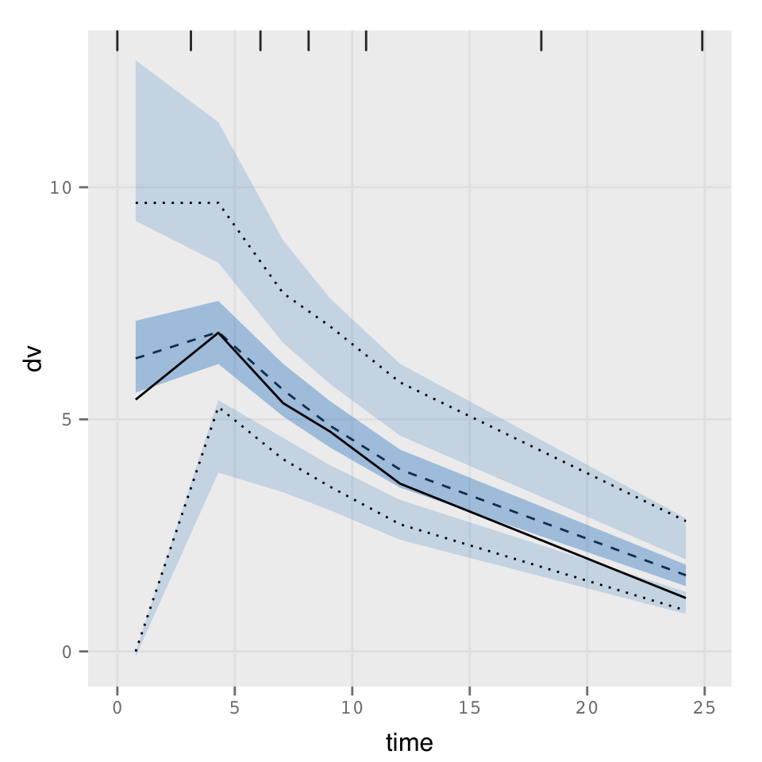

```r
vpc (sim = sim, obs = obs)
```

Stratified by SEX:

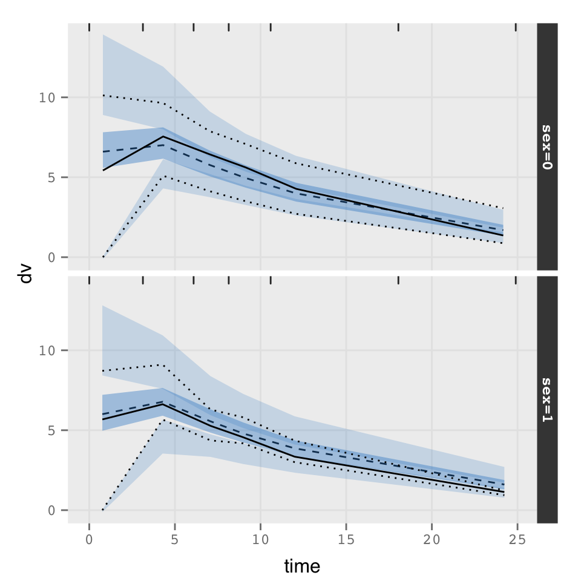

```r
vpc (sim = sim, obs = obs, stratify = c("sex"), facet = "rows")
```

The vpc functions in this packages allow stratification by 2 variables (horizontal and vertical faceting). If more strata are desired, a new combined variable should be defined that defines the factors.

Pred-correction, and plotting of data:

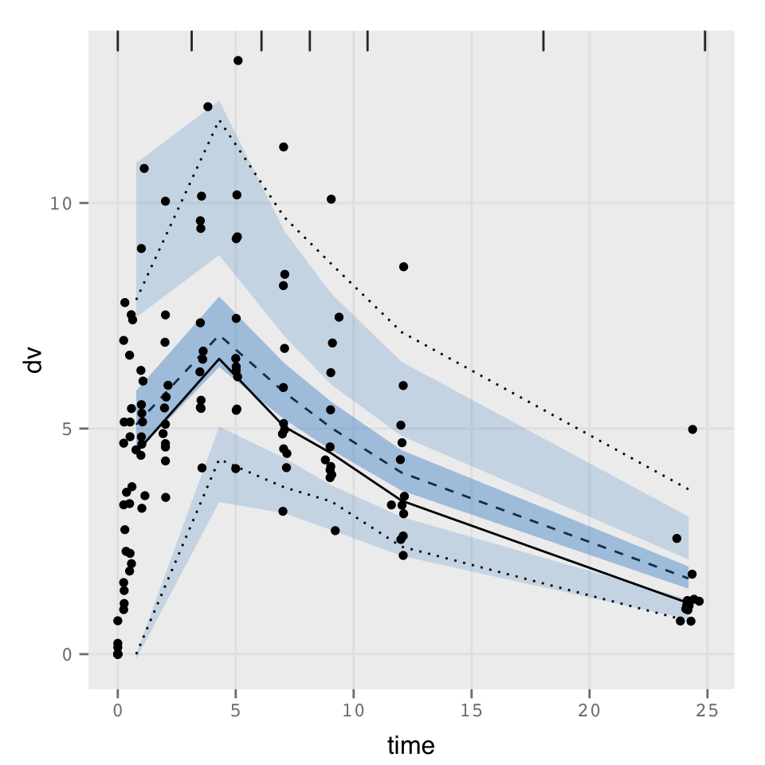

```r
vpc (sim = sim, obs = obs, pred_corr = TRUE, plot_dv = TRUE)
```

With more explicit use of options, and saving the object:

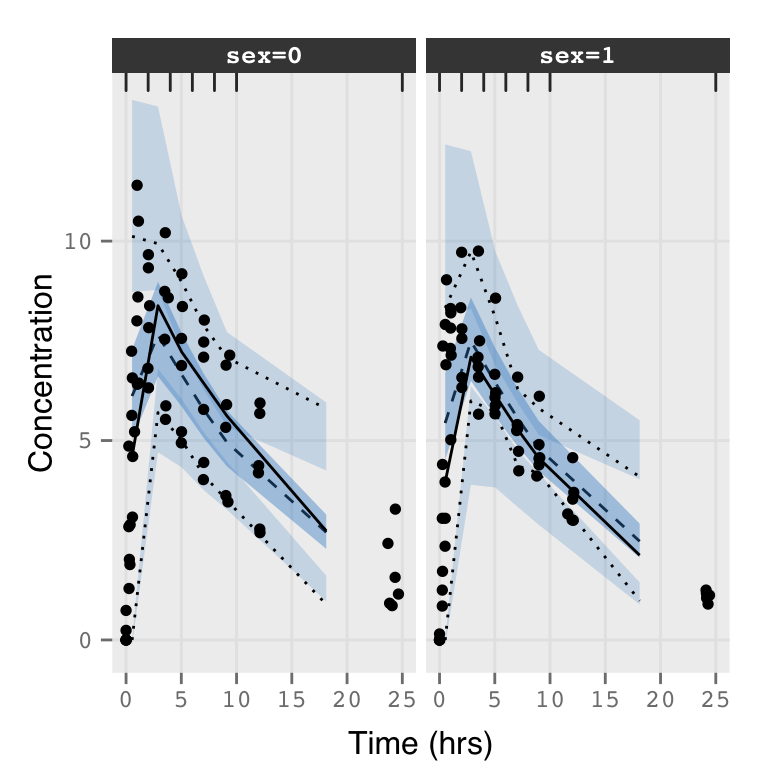

```r
vpc(sim = sim,
           obs = obs,                                   # supply simulation and observation dataframes
           obs_dv = "dv",                               # these column names are the default,
           obs_idv = "time",                            #   update these if different.
           sim_dv = "sdv",
           sim_idv = "time",
           bins = c(0, 2, 4, 6, 8, 10, 25),             # specify bin separators manually
           stratify = c("sex"),                         # multiple stratifications possible, just supply as vector
           pi = c(0.05, 0.95),                          # prediction interval simulated data to show
           ci = c(0.05, 0.95),                          # confidence intervals to show
           pred_corr = FALSE,                           # perform prediction-correction?
           plot_dv = TRUE,                              # plot observations?
           facet = "wrap",                              # wrap stratifications, or as "row" or "column"
           ylab = "Concentration",
            xlab = "Time (hrs)")
```

*Note: If you imported the data from NONMEM, the VPC function will automatically detect column names from NONMEM, such as ID, TIME, DV. If you simulated data in R or got the data from a different software, you will probably have to change the variable names for the dependent and independent variable, and the individual index.*

### Binning

- `time`: Divide bins equally over time (or whatever independent variable is used). Recommended only when there is no observable clustering in the independent variable.
- `data`: Divide bins equally over the amount of data ordered by independent variable. Recommended only when data are for nominal timepoints *and* all datapoints are available.
- `density`: Divide bins based on data-density, i.e. place the bin-separators at nadirs in the density function. An approximate number of bins can be specified, but it is not certain that the algorithm will strictly use the specified number. More info in `?auto_bin()`.
- `jenks`: Default and recommended method. Jenk’s natural breaks optimization, similar to K-means clustering.
- `kmeans`: K-means clustering.
- `pretty`, `quantile`, `hclust`, `sd`, `bclust`, `fisher`. Methods provided by the `classInt` package, see the package help for more information.

Automatic determination of *optimal* bin number (as described e.g. by Lavielle et al. and Sonehag et al.) will be provided soon.

### Censored data

The `vpc_cens()` function can be used to create a VPC for the probability of left- or right-censoring such as in the case of data ULOQ. There is no need to add a variable to the dataset to flag the censored cases, the function only requires the `lloq` or `uloq`. The example below artificially induces an LLOQ of 5 for the above model / dataset, and generates a VPC for the probability of left-censoring.

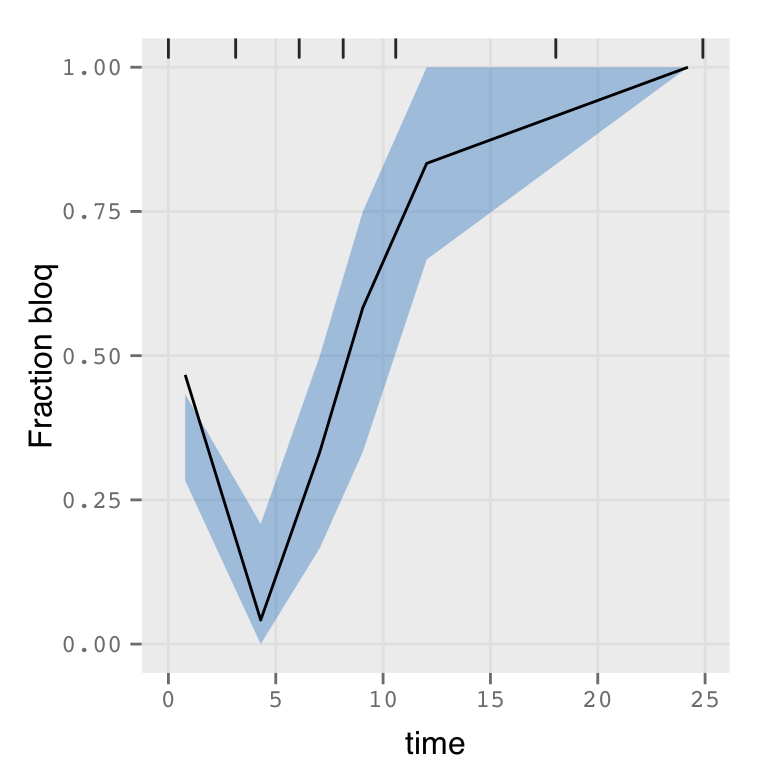

```r
vpc_cens(sim, obs, lloq = 5)
```

### Categorical data

VPCs can also be made for categorical data. These show the probability of observing a specific discrete outcome (or count), and plot this versus the simulated probability, shown as a confidence interval.

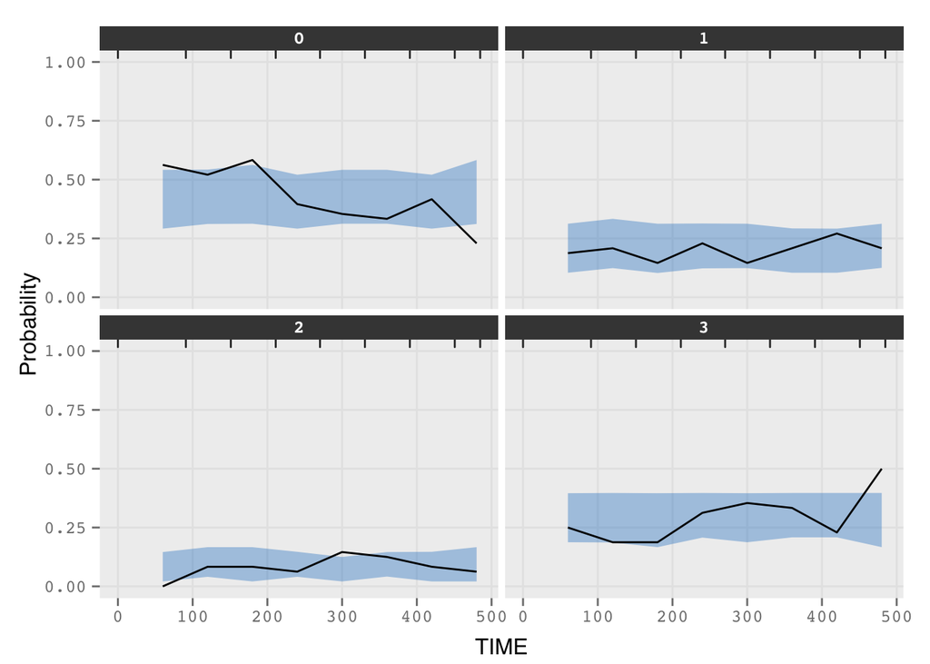

```r
obs_cat <- read_table_nm(file="~/git/vpc/nm/sdtab45")
sim_cat <- read_table_nm(file="~/git/vpc/nm/simtab45")
vpc_cat (sim = sim_cat, obs = obs_cat, nonmem = TRUE,
          obs_dv = "SMXH", sim_dv = "SMXH")
```

### Time-to-event data

Similar to the VPC for continuous data, the VPC for TTE data requires simulated data. In general, there are two distinct approach to simulate survival data:

- *Hazard integration*: Integrate the hazard over time, and at *any possible* observation timepoint randomly draw a binary value based on the probability of observing the event. The disadvantage of this method is that it is slow due to the numerical solving of the ODEs. Also, a dataset with a dense design grid has to be used for simulation, i.e. one that has observation times at every possible timepoint that an event can occur for all individuals.
- *Direct sampling*: Sample event times directly from the distribution used to model the data (e.g. Weibull, exponential, Gompertz). Advantages of this approach is that it is much faster, and it does not require a dense grid. The disadvantage with this approach is however that the hazard is assumed constant over time, so models with time-dependent hazards cannot easily be simulated with this approach. This approach is straightforward in R but cannot easily be implemented in NONMEM. Example will follow soon.

An example for time-to-event data is shown below. The datasets are supplied with the `vpc` library.

```r
data(rtte_obs_nm)
data(rtte_sim_nm)
```

Treat RTTE as TTE, no stratification:

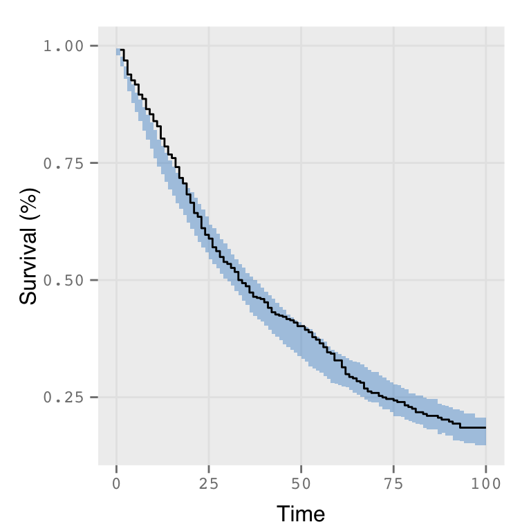

```r
vpc_tte(sim = rtte_sim_nm,
        obs = rtte_obs_nm,
        rtte = FALSE,
        sim_dv = "dv", obs_idv = "t", sim_idv = "t")
```

Stratified for covariate and study arm:

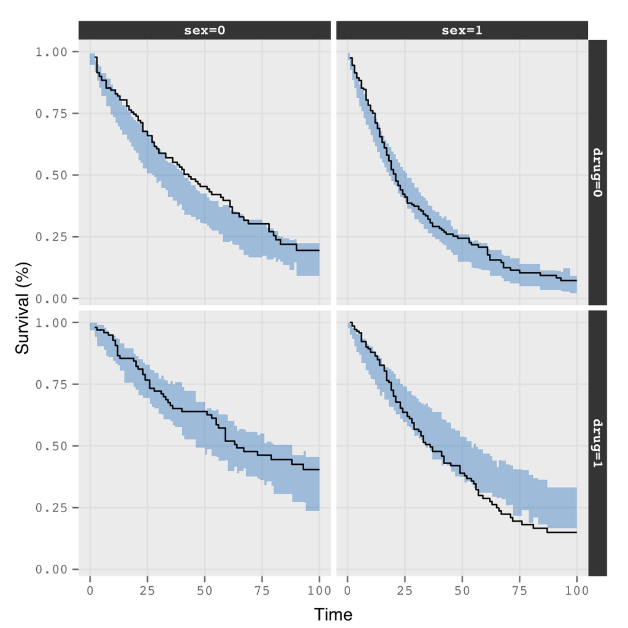

```r
vpc_tte(sim = rtte_sim_nm,
        obs = rtte_obs_nm,
        stratify = c("sex","drug"),
        rtte = FALSE,
        sim_dv = "dv", obs_idv = "t", sim_idv = "t")
```

Stratified for event number and study arm:

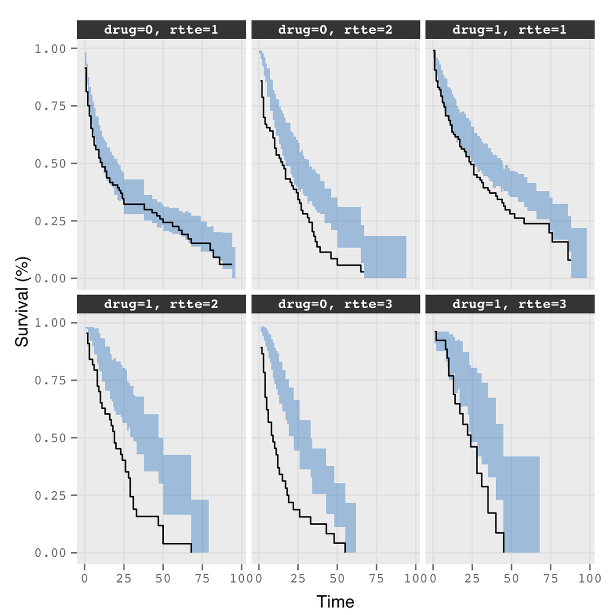

```r
vpc_tte(sim = rtte_sim_nm,
        obs = rtte_obs_nm,
        rtte = TRUE, events = c(1:3),
        stratify = c("drug"),
        sim_dv = "dv", obs_idv = "t", sim_idv = "t")
```